# The Cox Proportional Hazards Model

- Show All Code
- Hide All Code
- View Source

Regression Analysis for Survival Data (from chapter 5)

Author

Eric Delmelle

Published

October 1, 2025

[Link to qmd (quarto markdown)](https://github.com/BSTA-150/chapter5/blob/main/chapter5.qmd)

# Regression in Survival Analysis

- We learned how to compare survival distributions between groups using nonparametric methods like the log-rank test.
- Now we extend these ideas to **regression analysis** for survival data.

## Why Do We Need Regression for Survival Data?

When analyzing time-to-event data, we often face situations where:

- **Multiple factors** might influence survival (age, sex, treatment, biomarkers)
- We need to **adjust for confounding** variables
- Covariates are **continuous** (not just two groups)
- We want to **predict** survival for specific patient profiles
- We need to **quantify effects** while controlling for other variables

The **Cox Proportional Hazards Model** addresses all these needs while remaining flexible about the baseline hazard function.

## The Proportional Hazards Concept

From Chapter 4, recall that comparing two groups can be expressed as:

$$h_1(t) = \psi \cdot h_0(t)$$

- This **proportional hazards** relationship means the hazard ratio $\psi$ stays constant over time.
- The **Cox model** extends this idea to handle multiple covariates.

**Show setup code**

```r
# Load required packages
library(survival)
library(tidyverse)
library(knitr)
library(ggplot2)
library(survminer)

# Set plotting theme
theme_set(theme_minimal(base_size = 12))

# Custom colors
col_male <- "#E74C3C"
col_female <- "#3498DB"
```

# The Cox Proportional Hazards Model

## Model Formula

For an individual with covariate vector $\mathbf{z} = (z_1, z_2, \ldots, z_p)$, the Cox model specifies:

$$\boxed{h(t|\mathbf{z}) = h_0(t) \cdot \exp(\beta_1 z_1 + \beta_2 z_2 + \cdots + \beta_p z_p)}$$

Or more compactly:

$$h(t|\mathbf{z}) = h_0(t) \cdot \exp(\boldsymbol{\beta}^T \mathbf{z})$$

**Where:**

- $h_0(t)$ is the **baseline hazard** function (hazard when all covariates = 0)
  - Imagine a reference population (e.g., non-smokers, or women, or age = 0 if centered).
  - The **baseline hazard** describes how the risk evolves over time in this reference group.
  - Other groups are compared to this baseline by multiplying it by a factor.
  - Example: Baseline = “non-smokers”. If exp($\beta_1$)=2, then a “Smoker” has twice the risk at every instant.
- $\boldsymbol{\beta} = (\beta_1, \ldots, \beta_p)$ are **regression coefficients** to be estimated
- $\mathbf{z} = (z_1, \ldots, z_p)$ is the **covariate vector** for an individual
- The model is **semi-parametric**: no prior assumptions about $h_0(t)$ (like Exponential, Weibull)

## Why we use an Exponential function in Cox model?

**Four Key Reasons for Using $\exp(\boldsymbol{\beta}^T \mathbf{z})$**

You might wonder: why not just use $h(t|\mathbf{z}) = h_0(t) + \boldsymbol{\beta}^T \mathbf{z}$?

**1. Guarantees Positive Hazard**

- The hazard rate $h(t)$ can **never be negative** (it’s a rate)
- A linear combination $\boldsymbol{\beta}^T \mathbf{z}$ could produce negative values
- But $\exp(\text{anything}) > 0$ always!

**2. Multiplicative Interpretation (Hazard Ratios)**

- We get simple, interpretable **hazard ratios**
- HR = 2 means “twice the hazard”
- HR = 0.5 means “half the hazard”

**3. Proportional Hazards Property**

- The effect **multiplies** the baseline hazard at all times
- This maintains the proportional hazards assumption
- The ratio $h_1(t)/h_0(t)$ is constant over time

**4. Linear on Log Scale**

- Taking logs: $\log h(t|\mathbf{z}) = \log h_0(t) + \boldsymbol{\beta}^T \mathbf{z}$
- This is a **linear model** for log hazard
- Similar to logistic regression: $\log\left(\frac{p}{1-p}\right) = \beta_0 + \beta_1 X$

### Intuitive Analogy

Think of $h_0(t)$ as the **baseline volume** of music, and $\exp(\boldsymbol{\beta}^T \mathbf{z})$ as a **volume multiplier**:

- HR = 2.0 → doubles the volume
- HR = 0.5 → halves the volume
- HR = 1.0 → no change
- **Volume never becomes negative!**

## Understanding Hazard Ratios

For two individuals with covariate vectors $\mathbf{z}_i$ and $\mathbf{z}_j$:

$$\text{HR}_{i,j} = \frac{h(t|\mathbf{z}_i)}{h(t|\mathbf{z}_j)} = \frac{h_0(t) \exp(\boldsymbol{\beta}^T \mathbf{z}_i)}{h_0(t) \exp(\boldsymbol{\beta}^T \mathbf{z}_j)}$$

**The baseline hazard cancels out:**

$$\boxed{\text{HR}_{i,j} = \exp[\boldsymbol{\beta}^T (\mathbf{z}_i - \mathbf{z}_j)]}$$

**Key insight**: The hazard ratio depends only on:

1. The **difference in covariate values** between individuals
2. The **regression coefficients** $\boldsymbol{\beta}$

This is powerful: we can estimate effects **without specifying** the form of $h_0(t)$.

# Application: Lung Cancer Survival Study

Let’s apply the Cox model to real data from a lung cancer clinical trial.

## The Dataset

```r
# Load lung cancer data
data(lung)

# Clean and prepare the data
lung_clean <- lung %>%
  mutate(
    sex = factor(sex, levels = 1:2, labels = c("Male", "Female")),
    status_binary = status - 1,  # Convert 1/2 to 0/1
    ph.ecog = factor(ph.ecog, levels = 0:3)
  ) %>%
  filter(complete.cases(age, sex, ph.karno, status))

# Summary statistics by sex
lung_summary <- lung_clean %>%
  group_by(sex) %>%
  summarise(
    n = n(),
    n_events = sum(status_binary),
    pct_events = round(100 * mean(status_binary), 1),
    median_time = median(time),
    mean_age = round(mean(age), 1),
    sd_age = round(sd(age), 1),
    mean_karno = round(mean(ph.karno), 1)
  )

kable(lung_summary,
      col.names = c("Sex", "N", "Events", "% Events", "Median Time",
                    "Mean Age", "SD Age", "Mean Karnofsky"),
      caption = "Table 1: Lung Cancer Dataset Summary Statistics")
```

Table 1: Lung Cancer Dataset Summary Statistics

| Sex | N | Events | % Events | Median Time | Mean Age | SD Age | Mean Karnofsky |
| --- | --- | --- | --- | --- | --- | --- | --- |
| Male | 137 | 111 | 81.0 | 225.0 | 63.4 | 9.2 | 81.8 |
| Female | 90 | 53 | 58.9 | 292.5 | 61.1 | 8.8 | 82.1 |

**Dataset description:**

- **n = 227 patients** from a lung cancer trial
- **Outcome**: time to death (in days)
- **Covariates**: age, sex, ECOG performance status, Karnofsky performance score
- **Censoring**: 27.8% of observations are censored

## Exploratory Survival Analysis

Before fitting the Cox model, let’s visualize survival by sex:

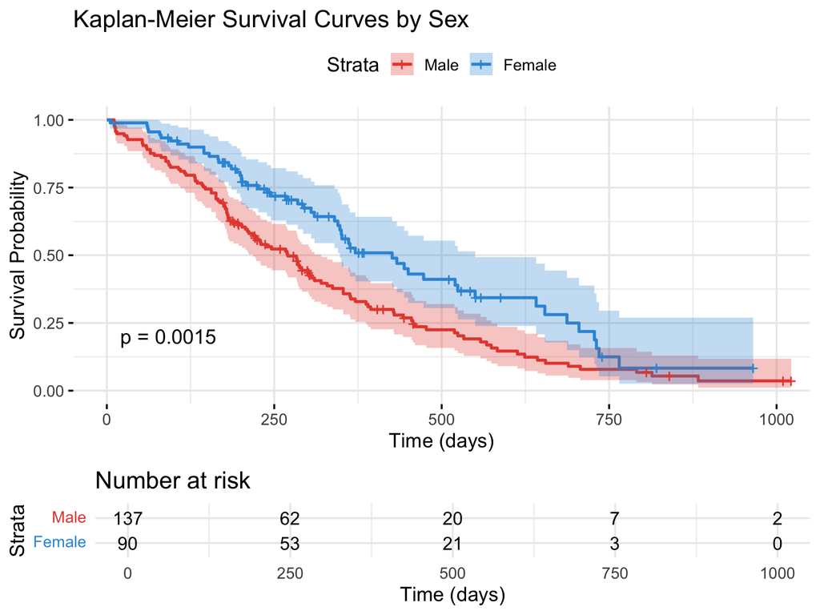

Figure 1: Kaplan-Meier survival curves by sex

```r
# Fit Kaplan-Meier curves
km_sex <- survfit(Surv(time, status_binary) ~ sex, data = lung_clean)

# Plot with survminer
ggsurvplot(km_sex,
           data = lung_clean,
           pval = TRUE,
           conf.int = TRUE,
           risk.table = TRUE,
           palette = c(col_male, col_female),
           xlab = "Time (days)",
           ylab = "Survival Probability",
           title = "Kaplan-Meier Survival Curves by Sex",
           legend.labs = c("Male", "Female"),
           ggtheme = theme_minimal(base_size = 14))
```

**Observation**: Females appear to have better survival than males (p < 0.05 by log-rank test).

## Fitting a Simple Cox Model

Let’s start with sex as the only predictor:

```r
# Fit Cox model with sex only
fit_sex <- coxph(Surv(time, status_binary) ~ sex, data = lung_clean)

# Display summary
summary(fit_sex)
```

```
Call:
coxph(formula = Surv(time, status_binary) ~ sex, data = lung_clean)

  n= 227, number of events= 164

             coef exp(coef) se(coef)      z Pr(>|z|)
sexFemale -0.5241    0.5921   0.1674 -3.131  0.00174 **
---
Signif. codes:  0 '***' 0.001 '**' 0.01 '*' 0.05 '.' 0.1 ' ' 1

          exp(coef) exp(-coef) lower .95 upper .95
sexFemale    0.5921      1.689    0.4265     0.822

Concordance= 0.578  (se = 0.021 )
Likelihood ratio test= 10.32  on 1 df,   p=0.001
Wald test            = 9.8  on 1 df,   p=0.002
Score (logrank) test = 10.02  on 1 df,   p=0.002
```

### Interpreting the Results

**Coefficient**: $\hat{\beta}_{\text{Female}} = -0.524$

**Hazard Ratio**: $\exp(\hat{\beta}) = 0.592$

**Interpretation**:

- Females have **40.8% lower hazard** of death compared to males
- Or equivalently: males have **1.69 times the hazard** of females
- The effect is **statistically significant** (p = 0.002)

### Visualizing the Effect

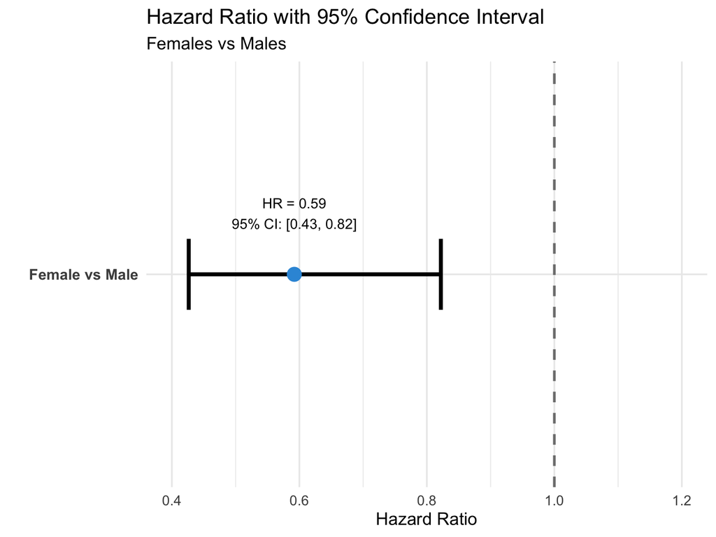

Figure 2: Hazard ratio for sex effect

```r
# Create data for forest plot
hr_data <- data.frame(
  Variable = "Female vs Male",
  HR = exp(coef(fit_sex)),
  Lower = exp(confint(fit_sex)[1]),
  Upper = exp(confint(fit_sex)[2])
)

ggplot(hr_data, aes(x = HR, y = Variable)) +
  geom_vline(xintercept = 1, linetype = "dashed", color = "gray50", linewidth = 1) +
  geom_errorbarh(aes(xmin = Lower, xmax = Upper), height = 0.2, linewidth = 1.5) +
  geom_point(size = 5, color = col_female) +
  geom_text(aes(label = sprintf("HR = %.2f\n95%% CI: [%.2f, %.2f]", HR, Lower, Upper)),
            vjust = -1.5, size = 4) +
  scale_x_continuous(breaks = seq(0.4, 1.2, 0.2), limits = c(0.4, 1.2)) +
  labs(title = "Hazard Ratio with 95% Confidence Interval",
       subtitle = "Females vs Males",
       x = "Hazard Ratio", y = "") +
  theme_minimal(base_size = 14) +
  theme(axis.text.y = element_text(size = 12, face = "bold"))
```

# Multiple Covariates Model

Now let’s build a more comprehensive model that adjusts for multiple factors.

## Adding Age and Performance Status

```r
# Fit Cox model with multiple covariates
fit_multi <- coxph(Surv(time, status_binary) ~ age + sex + ph.karno,
                   data = lung_clean)

summary(fit_multi)
```

```
Call:
coxph(formula = Surv(time, status_binary) ~ age + sex + ph.karno,
    data = lung_clean)

  n= 227, number of events= 164

               coef exp(coef)  se(coef)      z Pr(>|z|)
age        0.012375  1.012452  0.009405  1.316  0.18821
sexFemale -0.497170  0.608249  0.167713 -2.964  0.00303 **
ph.karno  -0.013322  0.986767  0.005880 -2.266  0.02348 *
---
Signif. codes:  0 '***' 0.001 '**' 0.01 '*' 0.05 '.' 0.1 ' ' 1

          exp(coef) exp(-coef) lower .95 upper .95
age          1.0125     0.9877    0.9940    1.0313
sexFemale    0.6082     1.6441    0.4378    0.8450
ph.karno     0.9868     1.0134    0.9755    0.9982

Concordance= 0.637  (se = 0.025 )
Likelihood ratio test= 18.81  on 3 df,   p=3e-04
Wald test            = 18.73  on 3 df,   p=3e-04
Score (logrank) test = 19.05  on 3 df,   p=3e-04
```

### Interpreting Multiple Coefficients

Let’s break down each covariate:

```r
# Extract coefficients and create summary table
coef_summary <- data.frame(
  Covariate = c("Age (per year)", "Sex: Female", "Karnofsky Score (per point)"),
  Beta = coef(fit_multi),
  HR = exp(coef(fit_multi)),
  Lower_CI = exp(confint(fit_multi)[,1]),
  Upper_CI = exp(confint(fit_multi)[,2]),
  P_value = summary(fit_multi)$coefficients[,5]
)

kable(coef_summary,
      digits = c(0, 3, 3, 3, 3, 4),
      col.names = c("Covariate", "β", "HR", "95% CI Lower", "95% CI Upper", "P-value"),
      caption = "Table 2: Cox Model Coefficients and Hazard Ratios")
```

Table 2: Cox Model Coefficients and Hazard Ratios

|  | Covariate | β | HR | 95% CI Lower | 95% CI Upper | P-value |
| --- | --- | --- | --- | --- | --- | --- |
| age | Age (per year) | 0.012 | 1.012 | 0.994 | 1.031 | 0.1882 |
| sexFemale | Sex: Female | -0.497 | 0.608 | 0.438 | 0.845 | 0.0030 |
| ph.karno | Karnofsky Score (per point) | -0.013 | 0.987 | 0.975 | 0.998 | 0.0235 |

**Age**:

- $\exp(\hat{\beta}_{\text{age}}) = 1.012$
- Each additional year of age increases hazard by 1.25%
- For a 10-year difference: HR = $1.13$ (13% increase)

**Karnofsky Performance Score**:

- $\exp(\hat{\beta}_{\text{karno}}) = 0.987$
- Each 1-point increase in score reduces hazard by 1.3%
- For a 10-point difference: HR = $0.875$ (12.5% reduction)

### Forest Plot for Multiple Covariates

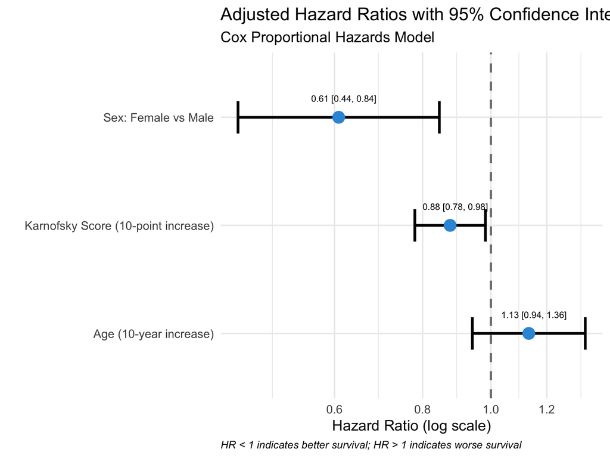

Figure 3: Forest plot of hazard ratios for multiple covariates

```r
# Prepare data for forest plot (using meaningful scales)
forest_data <- data.frame(
  Variable = c("Age (10-year increase)",
               "Sex: Female vs Male",
               "Karnofsky Score (10-point increase)"),
  HR = c(exp(10 * coef(fit_multi)["age"]),
         exp(coef(fit_multi)["sexFemale"]),
         exp(10 * coef(fit_multi)["ph.karno"])),
  Lower = c(exp(10 * confint(fit_multi)["age", 1]),
            exp(confint(fit_multi)["sexFemale", 1]),
            exp(10 * confint(fit_multi)["ph.karno", 1])),
  Upper = c(exp(10 * confint(fit_multi)["age", 2]),
            exp(confint(fit_multi)["sexFemale", 2]),
            exp(10 * confint(fit_multi)["ph.karno", 2]))
)

ggplot(forest_data, aes(y = reorder(Variable, -HR), x = HR)) +
  geom_vline(xintercept = 1, linetype = "dashed", color = "gray50", linewidth = 1) +
  geom_errorbarh(aes(xmin = Lower, xmax = Upper), height = 0.3, linewidth = 1.2) +
  geom_point(size = 5, color = "#3498DB") +
  geom_text(aes(label = sprintf("%.2f [%.2f, %.2f]", HR, Lower, Upper)),
            vjust = -2.4, hjust = .42, size = 3) +
  scale_x_log10(breaks = c(0.4, 0.6, 0.8, 1.0, 1.2, 1.5, 2.0)) +
  labs(title = "Adjusted Hazard Ratios with 95% Confidence Intervals",
       subtitle = "Cox Proportional Hazards Model",
       x = "Hazard Ratio (log scale)",
       y = "",
       caption = "HR < 1 indicates better survival; HR > 1 indicates worse survival") +
  theme_minimal(base_size = 14) +
  theme(plot.caption = element_text(hjust = 0, face = "italic", size = 10))
```

## Hypothesis Testing

The Cox model output provides **three hypothesis tests** for $H_0: \boldsymbol{\beta} = \mathbf{0}$ (no effect):

### 1. Wald Test

Uses the estimated coefficient and its standard error:

$$Z_w = \frac{\hat{\beta}}{s.e.(\hat{\beta})} \sim N(0, 1)$$

Most commonly reported in tables (z-statistic and p-value).

### 2. Score Test (Log-Rank)

For a single binary covariate, equivalent to the log-rank test. Uses the score function at $\beta = 0$.

### 3. Likelihood Ratio Test

Compares the log-likelihood of the full model to the null model. Most reliable for small samples and invariant to parameter transformations.

```r
# Extract test statistics
wald_stat <- summary(fit_multi)$waldtest[1]
score_stat <- summary(fit_multi)$sctest[1]
lr_stat <- summary(fit_multi)$logtest[1]

test_comparison <- data.frame(
  Test = c("Wald", "Score", "Likelihood Ratio"),
  Chi_square = c(wald_stat, score_stat, lr_stat),
  df = rep(3, 3),
  P_value = c(summary(fit_multi)$waldtest[3],
              summary(fit_multi)$sctest[3],
              summary(fit_multi)$logtest[3])
)

kable(test_comparison,
      digits = c(0, 2, 0, 5),
      col.names = c("Test", "χ²", "df", "P-value"),
      caption = "Table 3: Global Tests of Model Significance")
```

Table 3: Global Tests of Model Significance

| Test | χ² | df | P-value |
| --- | --- | --- | --- |
| Wald | 18.73 | 3 | 0.00031 |
| Score | 19.05 | 3 | 0.00027 |
| Likelihood Ratio | 18.81 | 3 | 0.00030 |

All three tests strongly reject the null hypothesis that all coefficients are zero (p < 0.001).

# Predicted Survival Curves

One of the most useful applications of the Cox model is predicting survival for individuals with specific covariate patterns.

## Creating Patient Profiles

```r
# Define typical patient profiles
patient_profiles <- data.frame(
  Profile = c("Young Male, Good Status",
              "Young Female, Good Status",
              "Older Male, Poor Status",
              "Older Female, Poor Status"),
  age = c(50, 50, 70, 70),
  sex = factor(c("Male", "Female", "Male", "Female")),
  ph.karno = c(90, 90, 70, 70)
)

kable(patient_profiles,
      caption = "Table 4: Patient Profiles for Prediction")
```

Table 4: Patient Profiles for Prediction

| Profile | age | sex | ph.karno |
| --- | --- | --- | --- |
| Young Male, Good Status | 50 | Male | 90 |
| Young Female, Good Status | 50 | Female | 90 |
| Older Male, Poor Status | 70 | Male | 70 |
| Older Female, Poor Status | 70 | Female | 70 |

## Computing Survival Curves

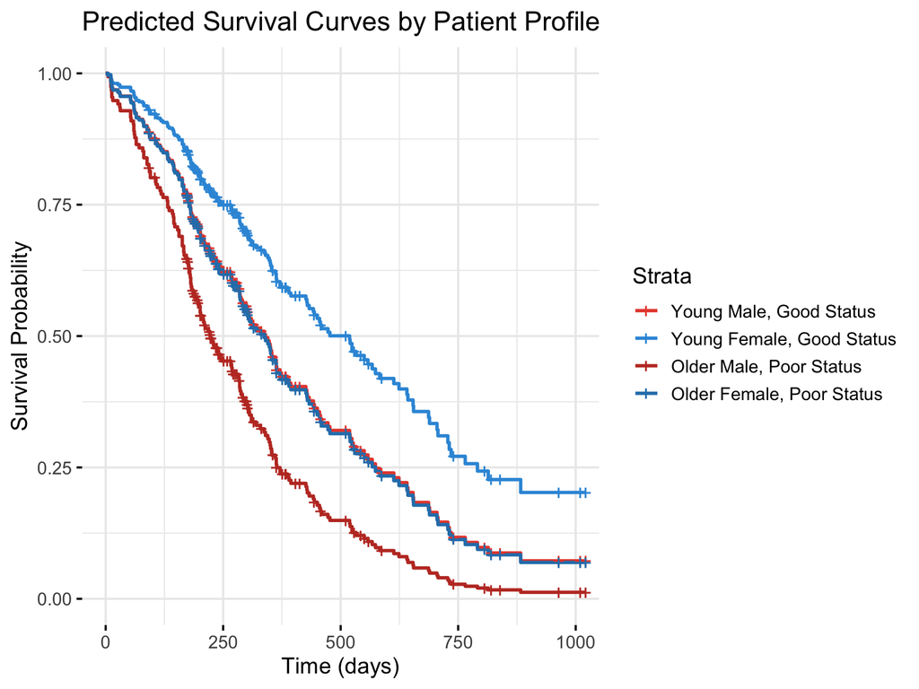

Figure 4: Predicted survival curves for different patient profiles

```r
# Generate survival curves for each profile
surv_pred <- survfit(fit_multi, newdata = patient_profiles)

# Plot with ggsurvplot
ggsurvplot(surv_pred,
           data = patient_profiles,
           conf.int = FALSE,
           legend.labs = patient_profiles$Profile,
           palette = c("#E74C3C", "#3498DB", "#C0392B", "#2980B9"),
           xlab = "Time (days)",
           ylab = "Survival Probability",
           title = "Predicted Survival Curves by Patient Profile",
           ggtheme = theme_minimal(base_size = 14),
           legend = "right")
```

### Predicted Median Survival Times

```r
# Extract median survival times
median_survival <- summary(surv_pred)$table[, "median"]

median_table <- data.frame(
  Profile = patient_profiles$Profile,
  Predicted_Median_Survival = round(median_survival, 0)
)

kable(median_table,
      col.names = c("Patient Profile", "Predicted Median Survival (days)"),
      caption = "Table 5: Predicted Median Survival Times")
```

Table 5: Predicted Median Survival Times

| Patient Profile | Predicted Median Survival (days) |
| --- | --- |
| Young Male, Good Status | 340 |
| Young Female, Good Status | 519 |
| Older Male, Poor Status | 223 |
| Older Female, Poor Status | 337 |

**Key observations**:

- **Sex effect**: Females consistently have better survival than males with similar characteristics
- **Age effect**: Older patients have shorter survival times
- **Performance status**: Better Karnofsky scores dramatically improve survival
- **Combined effects**: A 70-year-old male with poor performance has substantially worse prognosis than a 50-year-old female with good performance

# Model Diagnostics and Assumptions

The Cox model makes an important assumption: **proportional hazards**. Let’s verify this and check other model assumptions.

## Testing the Proportional Hazards Assumption

The proportional hazards assumption states that hazard ratios are **constant over time**. We can test this using **Schoenfeld residuals**.

```r
# Test proportional hazards assumption
ph_test <- cox.zph(fit_multi)
print(ph_test)
```

```
          chisq df      p
age       0.478  1 0.4892
sex       3.085  1 0.0790
ph.karno  8.017  1 0.0046
GLOBAL   10.359  3 0.0157
```

**Interpretation**:

- **p-value > 0.05**: No evidence against PH assumption
- **p-value < 0.05**: PH assumption may be violated

### Visualizing Schoenfeld Residuals

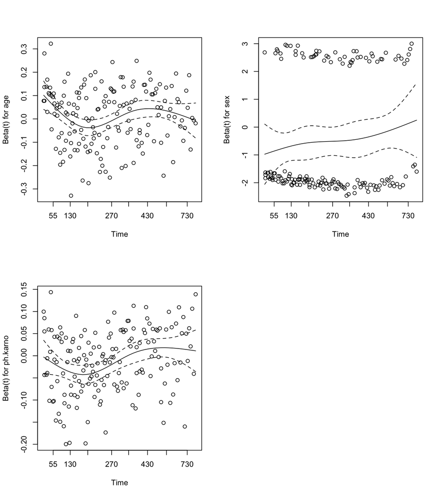

Figure 5: Schoenfeld residual plots for assessing proportional hazards

```r
# Create plots for each covariate
par(mfrow = c(2, 2))
plot(ph_test)
par(mfrow = c(1, 1))
```

**What to look for**:

- **Flat trend** (horizontal line) → PH assumption holds
- **Clear pattern** (upward/downward trend) → potential PH violation
- The smooth curve should be relatively flat around zero

## Checking Functional Form: Martingale Residuals

For continuous covariates (like age), we should verify that the **linear relationship** is appropriate.

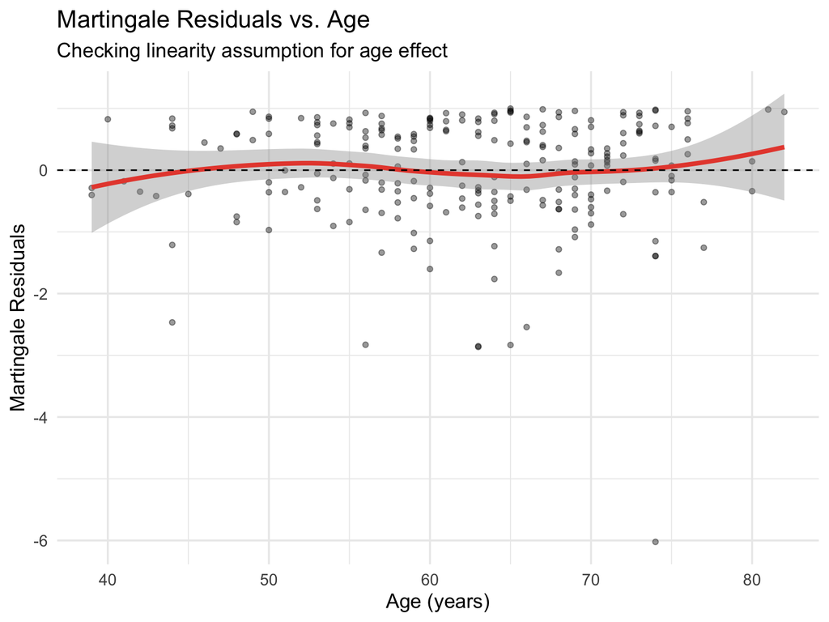

Figure 6: Martingale residuals vs. age

```r
# Calculate martingale residuals
mart_resid <- residuals(fit_multi, type = "martingale")

# Plot against age
lung_clean %>%
  mutate(mart_resid = mart_resid) %>%
  ggplot(aes(x = age, y = mart_resid)) +
  geom_point(alpha = 0.4) +
  geom_smooth(method = "loess", color = "#E74C3C", se = TRUE, linewidth = 1.5) +
  geom_hline(yintercept = 0, linetype = "dashed") +
  labs(title = "Martingale Residuals vs. Age",
       subtitle = "Checking linearity assumption for age effect",
       x = "Age (years)",
       y = "Martingale Residuals") +
  theme_minimal(base_size = 14)
```

**Interpretation**:

- If the smooth curve is approximately **linear**, the linear form is appropriate
- **Non-linear patterns** suggest we might need transformations (e.g., age², log(age), splines)
- Our plot shows a reasonably linear relationship

## Identifying Influential Observations

**Deviance residuals** help identify outliers or influential observations.

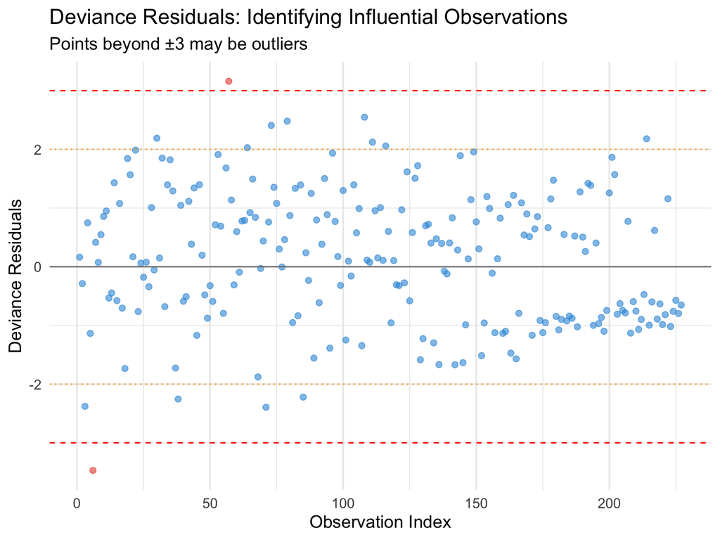

Figure 7: Deviance residuals for identifying outliers

```r
# Calculate deviance residuals
dev_resid <- residuals(fit_multi, type = "deviance")

# Create index plot
lung_clean %>%
  mutate(
    dev_resid = dev_resid,
    obs_id = row_number(),
    outlier = abs(dev_resid) > 3
  ) %>%
  ggplot(aes(x = obs_id, y = dev_resid, color = outlier)) +
  geom_point(alpha = 0.6, size = 2) +
  geom_hline(yintercept = c(-3, -2, 0, 2, 3),
             linetype = c("dashed", "dotted", "solid", "dotted", "dashed"),
             color = c("red", "orange", "gray50", "orange", "red")) +
  scale_color_manual(values = c("FALSE" = "#3498DB", "TRUE" = "#E74C3C")) +
  labs(title = "Deviance Residuals: Identifying Influential Observations",
       subtitle = "Points beyond ±3 may be outliers",
       x = "Observation Index",
       y = "Deviance Residuals") +
  theme_minimal(base_size = 14) +
  theme(legend.position = "none")
```

**Guidelines**:

- Residuals between **±2**: typical
- Residuals beyond **±2**: potentially unusual
- Residuals beyond **±3**: likely outliers (investigate further)

```r
# Identify extreme residuals
n_outliers <- sum(abs(dev_resid) > 3)
pct_outliers <- round(100 * n_outliers / length(dev_resid), 1)

cat(sprintf("Number of potential outliers (|residual| > 3): %d (%.1f%%)\n",
            n_outliers, pct_outliers))
```

```
Number of potential outliers (|residual| > 3): 2 (0.9%)
```

## Model Comparison: Which Model is Better?

Let’s compare our multiple covariate model to simpler alternatives using the **Akaike Information Criterion (AIC)**.

```r
# Fit alternative models
fit_null <- coxph(Surv(time, status_binary) ~ 1, data = lung_clean)
fit_sex_only <- coxph(Surv(time, status_binary) ~ sex, data = lung_clean)
fit_age_sex <- coxph(Surv(time, status_binary) ~ age + sex, data = lung_clean)
fit_full <- fit_multi

# Compare AIC values
model_comp <- data.frame(
  Model = c("Null (no predictors)",
            "Sex only",
            "Age + Sex",
            "Age + Sex + Karnofsky"),
  AIC = c(AIC(fit_null), AIC(fit_sex_only), AIC(fit_age_sex), AIC(fit_full)),
  n_parameters = c(0, 1, 2, 3)
) %>%
  arrange(AIC) %>%
  mutate(Delta_AIC = AIC - min(AIC))

kable(model_comp,
      digits = 1,
      caption = "Table 6: Model Comparison Using AIC")
```

Table 6: Model Comparison Using AIC

| Model | AIC | n_parameters | Delta_AIC |
| --- | --- | --- | --- |
| Age + Sex + Karnofsky | 1476.2 | 3 | 0.0 |
| Age + Sex | 1479.1 | 2 | 3.0 |
| Sex only | 1480.7 | 1 | 4.5 |
| Null (no predictors) | 1489.0 | 0 | 12.8 |

**Interpretation**:

- **Lower AIC is better** (indicates better model fit while penalizing complexity)
- Models with **ΔA IC < 2** are considered equivalent
- The full model (Age + Sex + Karnofsky) has the **lowest AIC**, suggesting it’s the best model

# Advanced Topics

## Stratified Cox Model

When the proportional hazards assumption is violated for a categorical variable, we can **stratify** by that variable:

```r
# Example: stratify by sex if PH assumption fails
fit_stratified <- coxph(Surv(time, status_binary) ~ age + ph.karno + strata(sex),
                        data = lung_clean)
```

This allows **different baseline hazards** for each sex while assuming age and Karnofsky score have the **same effects** across sexes.

## Time-Varying Covariates

When covariates change over time (e.g., treatment changes, biomarker values), we can model them as **time-dependent**:

$$h(t|\mathbf{z}(t)) = h_0(t) \exp[\boldsymbol{\beta}^T \mathbf{z}(t)]$$

This requires special data formatting (multiple rows per subject).

# Summary

**Key Takeaways**

**1. Cox Model Formula**
$$h(t|\mathbf{z}) = h_0(t) \cdot \exp(\boldsymbol{\beta}^T \mathbf{z})$$

**2. Why Exponential Function?**

- Guarantees positive hazard
- Multiplicative interpretation (hazard ratios)
- Maintains proportional hazards
- Linear on log scale

**3. Hazard Ratio Interpretation**
$$\text{HR} = \exp(\boldsymbol{\beta}^T \Delta \mathbf{z})$$

- HR > 1: increased hazard (worse survival)
- HR < 1: decreased hazard (better survival)
- HR = 1: no effect

**4. Model Assumptions**

- **Proportional hazards**: test with Schoenfeld residuals
- **Linearity**: check with martingale residuals
- **No influential outliers**: examine deviance residuals

**5. Multiple Covariates**

- Adjust for confounding
- Quantify independent effects
- Make predictions for specific profiles

**6. Practical Modeling Steps**

1. Explore data with Kaplan-Meier curves
2. Fit Cox model with relevant covariates
3. Interpret hazard ratios and p-values
4. Check model assumptions
5. Compare alternative models
6. Generate predicted survival curves

# Exercises

## Exercise 1: Basic Cox Model

Using the `aml` dataset from the `survival` package:

```r
data(aml)
head(aml)
```

```
  time status          x
1    9      1 Maintained
2   13      1 Maintained
3   13      0 Maintained
4   18      1 Maintained
5   23      1 Maintained
6   28      0 Maintained
```

**Tasks**:

1. Fit a Cox model comparing maintained vs. non-maintained groups
2. Interpret the hazard ratio
3. Is the treatment effect statistically significant?
4. Plot the predicted survival curves for both groups

## Exercise 2: Multiple Covariates

Using the `lung` dataset:

**Tasks**:

1. Fit a model including: age, sex, ECOG performance status (`ph.ecog`), and weight loss (`wt.loss`)
2. Which variables are statistically significant?
3. Calculate the hazard ratio for a 10-year age difference
4. Create a forest plot of all hazard ratios

## Exercise 3: Model Diagnostics

For your model from Exercise 2:

**Tasks**:

1. Test the proportional hazards assumption
2. Create Schoenfeld residual plots
3. Check for outliers using deviance residuals
4. Is there evidence of any assumption violations?

## Exercise 4: Prediction

Using your model from Exercise 2:

**Tasks**:

1. Create three patient profiles:
   - Low risk: 50 years, female, ECOG=0, no weight loss
   - Medium risk: 65 years, male, ECOG=1, 5 lbs loss
   - High risk: 75 years, male, ECOG=2, 15 lbs loss
2. Plot predicted survival curves for these profiles
3. Calculate predicted median survival for each
4. What is the ratio of hazards between high-risk and low-risk patients?

## Exercise 5: Model Comparison

**Tasks**:

1. Fit three models: (1) sex only, (2) age + sex, (3) age + sex + ECOG + weight loss
2. Compare them using AIC
3. Which model would you choose and why?
4. Does adding ECOG and weight loss significantly improve the model? (Hint: use likelihood ratio test)

# References

**Primary Sources**:

- Cox, D.R. (1972). “Regression Models and Life-Tables.” *Journal of the Royal Statistical Society: Series B*, 34(2), 187-202.
- Cox, D.R. (1975). “Partial likelihood.” *Biometrika*, 62(2), 269-276.

**Textbooks**:

- Therneau, T.M. & Grambsch, P.M. (2000). *Modeling Survival Data: Extending the Cox Model*. Springer.
- Klein, J.P. & Moeschberger, M.L. (2003). *Survival Analysis: Techniques for Censored and Truncated Data*. Springer.
- Moore, D.F. (2016). *Applied Survival Analysis Using R*. Springer.
- Collett, D. (2015). *Modelling Survival Data in Medical Research* (3rd ed.). Chapman & Hall/CRC.

**R Packages**:

- Therneau, T. (2023). *survival*: Survival Analysis. R package.
- Kassambara, A. (2021). *survminer*: Drawing Survival Curves using ‘ggplot2’. R package.

**Statistical Theory**:

- Andersen, P.K., Borgan, O., Gill, R.D., & Keiding, N. (1993). *Statistical Models Based on Counting Processes*. Springer.
- Fleming, T.R. & Harrington, D.P. (2011). *Counting Processes and Survival Analysis*. Wiley.

[← Return to Course Materials](https://bsta-150.github.io/course/)